[figure not shown]

[figure not shown]

[figure not shown]

# Data Description

The data we have chosen for this project is the Australian Road Deaths Database (ARDD) provided by the Australian Bureau of Infrastructure and Transport Research Economics (BITRE). The records are updated monthly from 1986 to 2021. Here is the link to the database : https://data.gov.au/dataset/ds-dga-5b530fb8-526e-4fbf-b0f6-aa24e84e4277/details.

There are two data files. The fatality data contains the demographic and details of people who have died within 30 days of the traffic accident due to injuries caused by an Australia road crash. The fatal crashes data contains the records for the crash, including information like the road type, and speed limit. The two data files can be connected by the crash ID. See Appendix for more detailed descriptions of each variable.

# Research Questions:

Q1: What demographic has a higher rate of traffic accidents?

Q2: Ranking of vehicle types by number of accidents

Q3: How does the car accident fatality link with the district and accident type?

Q4: Is there any correlation between accidents and holiday? And why are some explanations for the relation(s) or lack thereof.

Q5 :Has accident rate decreased or increased within the past decade (2010- 2020)?

Q6: Possible correlations between number of fatalities and speed limit zone

```
  Crash.ID State Month Year Crash.Type Number.Fatalities Bus.Involvement
1 20202001   Vic    12 2020   Multiple                 1              No
2 20204057    SA    12 2020     Single                 1              No
3 20203145   Qld    12 2020     Single                 1              No
4 20203208   Qld    12 2020     Single                 1              No
5 20203117   Qld    12 2020   Multiple                 2              No
6 20201199   NSW    12 2020     Single                 1              No
  Heavy.Rigid.Truck.Involvement Articulated.Truck.Involvement Speed.Limit
1                            No                           Yes         100
2                            No                            No         100
3                            No                            No          60
4                            No                            No         100
5                            No                           Yes         100
6                            No                            No          50
  National.LGA.Name.2017 Christmas.Period Easter.Period Time.of.day
1           Horsham (RC)              Yes            No       Night
2           Tatiara (DC)               No            No         Day
3     Sunshine Coast (R)               No            No       Night
4          Bundaberg (R)              Yes            No       Night
5          Cloncurry (S)              Yes            No         Day
6          Upper Lachlan               No            No         Day
```

```
  Crash.ID State Month Year Crash.Type Bus.Involvement
1 20203116   Qld    12 2020   Multiple              No
2 20201210   NSW    12 2020     Single              No
3 20203202   Qld    12 2020     Single              No
4 20201093   NSW    12 2020     Single              No
5 20203161   Qld    12 2020   Multiple              No
6 20203179   Qld    12 2020   Multiple              No
  Heavy.Rigid.Truck.Involvement Articulated.Truck.Involvement Speed.Limit
1                            No                            No          60
2                            No                            No         100
3                            No                            No         100
4                            No                            No         100
5                            No                            No          70
6                            No                            No         100
         Road.User Gender Age National.LGA.Name.2017 Christmas.Period
1 Motorcycle rider   Male  28             Cairns (R)               No
2        Passenger   Male  89                 Walcha              Yes
3           Driver   Male  21    Charters Towers (R)              Yes
4           Driver   Male  81                 Walcha               No
5           Driver Female  66        Moreton Bay (R)               No
6        Passenger   Male  79     Lockyer Valley (R)               No
  Easter.Period   Age.Group Time.of.day
1            No    26_to_39       Night
2            No 75_or_older         Day
3            No    17_to_25         Day
4            No 75_or_older       Night
5            No    65_to_74       Night
6            No 75_or_older         Day
```

# Data Analysis

##Q3:

# District and Accident Type Analysis(Part A)

#How does the car accident fatality link with the district and accident type?

### Count of Vehicle Type of Fatal Car Accidents

| State | Type | Count |
| --- | --- | --- |
| ACT | Bus_Involved | 4 |
| ACT | Heavytruck_Involved | 3 |
| ACT | Articulated_truck_Involved | 6 |
| NSW | Bus_Involved | 75 |
| NSW | Heavytruck_Involved | 266 |
| NSW | Articulated_truck_Involved | 344 |
| NT | Bus_Involved | 6 |
| NT | Heavytruck_Involved | 5 |
| NT | Articulated_truck_Involved | 15 |
| Qld | Bus_Involved | 43 |
| Qld | Heavytruck_Involved | 144 |
| Qld | Articulated_truck_Involved | 278 |

### Number of Fatal Accidents with Different Car Type in Different State

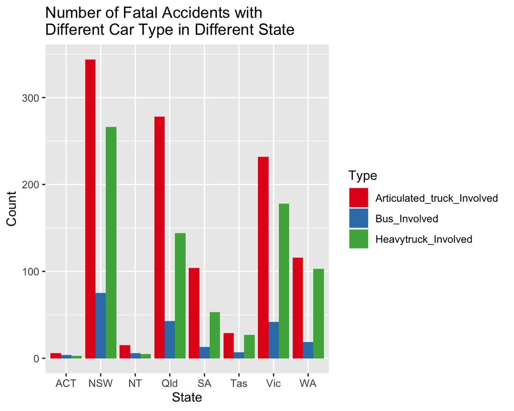

### Count of Different Road User of Fatal Car Accidents

| State | Road.User | Count |
| --- | --- | --- |
| ACT | Driver | 47 |
| ACT | Motorcycle pillion passenger | 1 |
| ACT | Motorcycle rider | 24 |
| ACT | Passenger | 16 |
| ACT | Pedal cyclist | 7 |
| ACT | Pedestrian | 11 |
| NSW | Driver | 1832 |
| NSW | Motorcycle pillion passenger | 24 |
| NSW | Motorcycle rider | 644 |
| NSW | Passenger | 689 |
| NSW | Pedal cyclist | 110 |
| NSW | Pedestrian | 596 |

### Number of Fatal Accidents with Different Road User in Different State

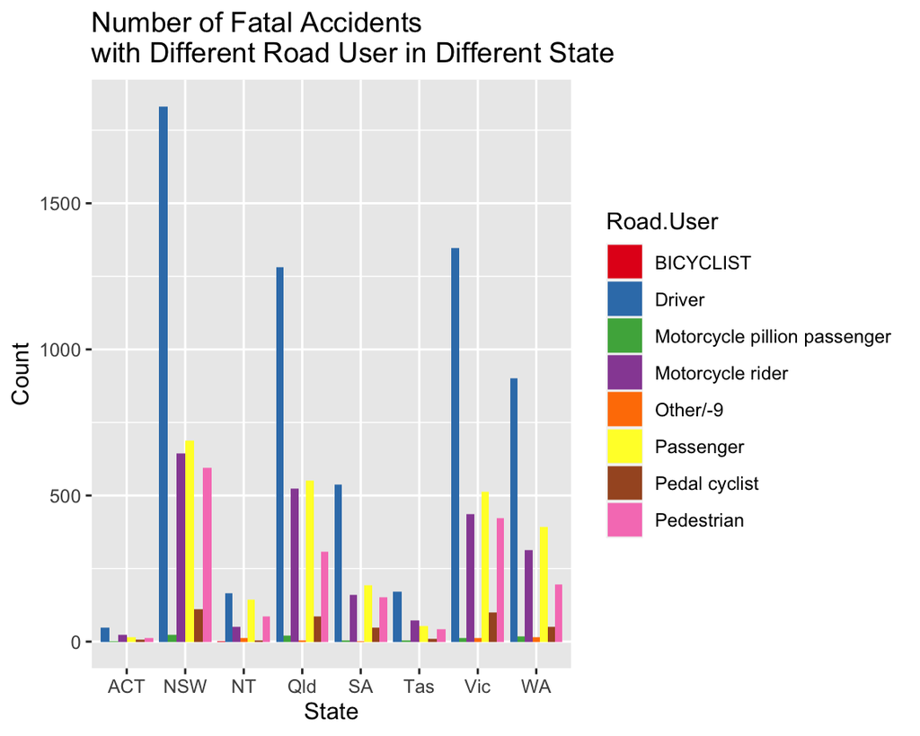

# District and Accident Type Analysis(Part B)

### Count of Different Crash Type of Fatal Car Accidents

| State | Crash.Type | Count |
| --- | --- | --- |
| ACT | Multiple | 57 |
| ACT | Single | 49 |
| NSW | Multiple | 1783 |
| NSW | Single | 2112 |
| NT | Multiple | 129 |
| NT | Single | 333 |
| Qld | Multiple | 1244 |
| Qld | Single | 1531 |
| SA | Multiple | 488 |
| SA | Single | 608 |
| Tas | Multiple | 210 |
| Tas | Single | 145 |

### Number of Fatal Accidents with Different Crash Type in Different State

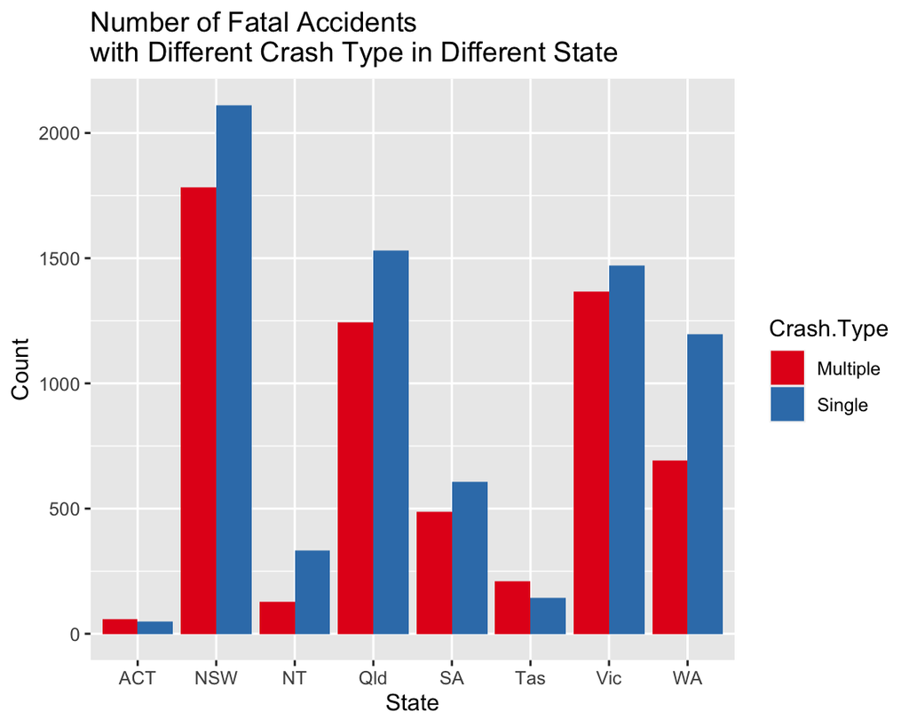

### Count of Fatal Car Accidents in Different District with NA Value

| State | National.LGA.Name.2017 | n |
| --- | --- | --- |
| Qld | NA | 1786 |
| NSW | NA | 1778 |
| Vic | NA | 1638 |
| WA | NA | 954 |
| SA | NA | 415 |
| NT | NA | 220 |
| Tas | NA | 124 |
| Qld | Brisbane (C) | 87 |
| NSW | Central Coast | 82 |
| Qld | Gold Coast (C) | 68 |
| Qld | Moreton Bay (R) | 62 |
| ACT | NA | 60 |

### Count of Fatal Car Accidents in Different District without NA Value

| State | National.LGA.Name.2017 | n |
| --- | --- | --- |
| Qld | Brisbane (C) | 87 |
| NSW | Central Coast | 82 |
| Qld | Gold Coast (C) | 68 |
| Qld | Moreton Bay (R) | 62 |
| NSW | Lake Macquarie | 56 |
| NSW | Shoalhaven | 55 |
| NSW | Mid-Coast | 54 |
| Qld | Logan (C) | 54 |
| Qld | Bundaberg (R) | 53 |
| Qld | Sunshine Coast (R) | 52 |
| NSW | Clarence Valley | 50 |
| ACT | Unincorporated ACT | 46 |